# Homework 2

```r
#Was not able to get the legend to show correctly, I realize that color should be set to state, except each line would have ended up being colored differently depending on the state. On top of the previous issue, the color has flipped the labels for some reason that I don't understand, so I hope that you could clarify that for me in the comments of my submission!
```

Q3) We want to create a side-by-side boxplot of reported crimes (Count) for violent and non-violent crime (Violent.crime). I’ve taken log(Count) so that the data is easier to visualize. However, the following code doesn’t produce what I expected. Debug this code to produce the plot that we want. Add the appropriate labels.

```r
#Original Code
#ggplot(fbi,aes(log(Count),Violent.crime)) + geom_boxplot() + coord_flip()
head(fbi)
```

```
##     State Abb Year Population                                 Type Count
## 1 Alabama  AL 1961    3302000 Murder.and.nonnegligent.Manslaughter   427
## 2 Alabama  AL 1962    3358000 Murder.and.nonnegligent.Manslaughter   316
## 3 Alabama  AL 1963    3347000 Murder.and.nonnegligent.Manslaughter   340
## 4 Alabama  AL 1964    3407000 Murder.and.nonnegligent.Manslaughter   316
## 5 Alabama  AL 1965    3462000 Murder.and.nonnegligent.Manslaughter   395
## 6 Alabama  AL 1966    3517000 Murder.and.nonnegligent.Manslaughter   384
##   Violent.crime
## 1          TRUE
## 2          TRUE
## 3          TRUE
## 4          TRUE
## 5          TRUE
## 6          TRUE
```

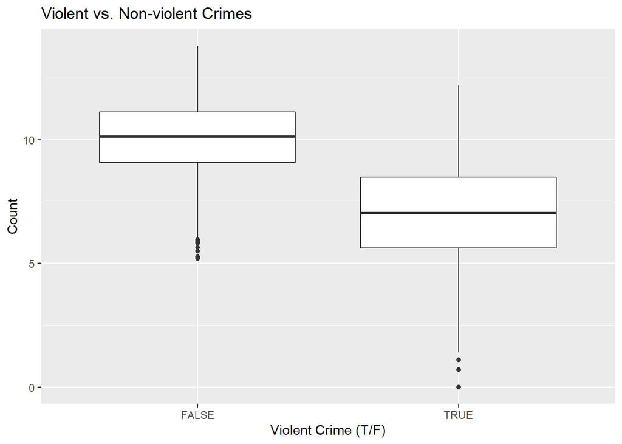

```r
#I ended up switching the variable assignments, with violent crimes on the x axis, and log(count) on  the y axis. I also removed coord_flip() since it made the boxplot horizontal instead of vertical.
ggplot(fbi,aes(x = fbi$Violent.crime, y=log(Count) )) + geom_boxplot() + labs(x = "Violent Crime (T/F)", y = "Count", title = "Violent vs. Non-violent Crimes")
```

Q4) What happens if you try to facet on a continuous variable? A4) There ends up being 1 facet graph for each value. Using the same mpg dataset from question 1, I facet_wrapped by city fuel economy for the cars, while making the x-value of the plot the city fuel economy as well. This shows a plot for every value of cty, see example plot below for details.

```r
head(mpg)
```

```
## # A tibble: 6 x 11
##   manufacturer model displ  year   cyl trans  drv     cty   hwy fl    class
##   <chr>        <chr> <dbl> <int> <int> <chr>  <chr> <int> <int> <chr> <chr>
## 1 audi         a4      1.8  1999     4 auto(~ f        18    29 p     comp~
## 2 audi         a4      1.8  1999     4 manua~ f        21    29 p     comp~
## 3 audi         a4      2    2008     4 manua~ f        20    31 p     comp~
## 4 audi         a4      2    2008     4 auto(~ f        21    30 p     comp~
## 5 audi         a4      2.8  1999     6 auto(~ f        16    26 p     comp~
## 6 audi         a4      2.8  1999     6 manua~ f        18    26 p     comp~
```

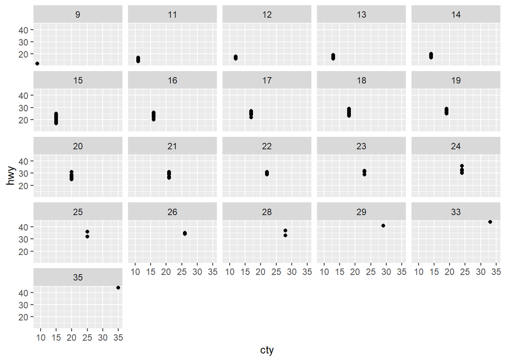

```r
ggplot(mpg, aes(x = cty, y = hwy)) + geom_point() + facet_wrap(~ cty)
```

```r
#Inspired by an example in a Data Visualization tutorial on Amazon Web Services' website (https://rstudio-pubs-static.s3.amazonaws.com/271994_11b7ddf08518406c942009d2da632982.html).I changed the continuous variable by which we facet_wrap as well as the x variable that I use for the plot. Edited the syntax to follow how we've been using facet_wrap in class for consistency.
```

Part 2 - Data Exploration: Cars and Mileage For this part we will use the mpg data set and the diamonds dataset. You can access both by loading the package ggplot2 into your R session by executing the command library(ggplot2).

The mpg data includes information about fuel economy of popular car models for the years 1999 and 2008 as collected by the US Environmental Protection Agency.

The diamonds data inclues information about the prices and attributes of almost 54,000 diamonds.

An answer should include a short paragraph of text for the explanation to a (human) reader, together with appropriate R code, outputs, and graphs.

Q5) Critique this plot. What do you think is a problematic feature of this plot and why does it not convey all of the relevant information? Propose an improved plot. Incldue your code. Hint: look carefully at the values for the variables cty and hwy.